```python
%%javascript
$.getScript('https://kmahelona.github.io/ipython_notebook_goodies/ipython_notebook_toc.js')
```

# Matplotlib

As its name suggests, Matplotlib is a library for creating plots, graphs, charts, etc., of data. Its syntax is influenced by Matlab. It is possbile visualize data contained in simple lists and tuples, but Matplotlib can also work effectively NumPy and Pandas data structures. Below, we will specifically work with the `pyplot` routines

**See**

- https://matplotlib.org/users/pyplot_tutorial.html

## A Simple Plot

Below we create a plot from two data lists `x` `y` using `plot()`. We also specify text for the x-axis and y-axis as well as give the plot a title.

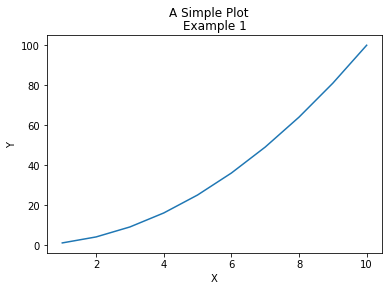

```python
import numpy as np
import matplotlib
import matplotlib.pyplot as plt # pyplot gives a matlab like feel.
# need the below for presenting plots in Jupyiter notebook.
%matplotlib inline

x = [1,2,3,4,5,6,7,8,9,10]
y = [1,4,9,16,25,36,49,64,81,100]
result = plt.plot(x,y)
plt.xlabel('X')
plt.ylabel('Y')
plt.title('Example 1')
plt.suptitle('A Simple Plot')
plt.show()
```

An even simpler plot can be created by providing only a single list of numbers. These are taken as $y$ values. The corresponding $x$ values are just the sequence $0,1,2,\ldots$.

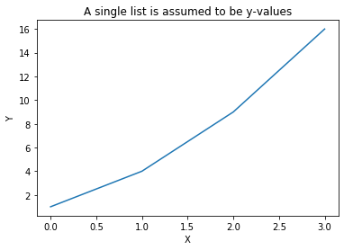

```python
plt.plot([1,4,9,16])
plt.xlabel('X')
plt.ylabel('Y')
plt.title('A single list is assumed to be y-values')
plt.show()
```

We can adjust the viewable axes using `plot.axis([xmin,xmax,ymin,ymax])`

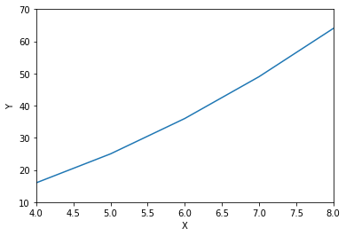

```python
x = [1,2,3,4,5,6,7,8,9,10]
y = [1,4,9,16,25,36,49,64,81,100]
plt.plot(x,y)
plt.xlabel('X')
plt.ylabel('Y')
plt.axis([4,8,10,70])
plt.show()
```

## Formatting points

An optional string can be used to format the plotted data. The format is based on that of Matlab. E.g., `r*` will make red stars, `b-` will make a solid blue line.

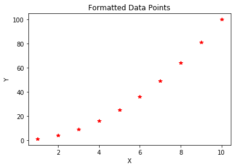

```python
plt.plot(x,y,'r*') # 'r*' is a matlab-like formatting string; 'r' for red, '*' for stars
plt.xlabel('X')
plt.ylabel('Y')
plt.title('Formatted Data Points')
plt.show()
```

The following are taken from https://matplotlib.org/users/pyplot_tutorial.html.

**Line Styles**

| character | description |
| --- | --- |
| '-' | solid line style |
| '--' | dashed line style |
| '-.' | dash-dot line style |
| ':' | dotted line style |
| '.' | point marker |
| ',' | pixel marker |
| 'o' | circle marker |
| 'v' | triangle_down marker |
| '^' | triangle_up marker |
| '<' | triangle_left marker |
| '>' | triangle_right marker |
| '1' | tri_down marker |
| '2' | tri_up marker |
| '3' | tri_left marker |
| '4' | tri_right marker |
| 's' | square marker |
| 'p' | pentagon marker |
| '*' | star marker |
| 'h' | hexagon1 marker |
| 'H' | hexagon2 marker |
| '+' | plus marker |
| 'x' | x marker |
| 'D' | diamond marker |
| 'd' | thin_diamond marker |
| '_' | hline marker |

**Colors**

| character | color |
| --- | --- |
| b | blue |
| g | green |
| r | red |
| c | cyan |
| m | magenta |
| y | yellow |
| k | black |
| w | white |

## Formatting multiple series

In general, `plt.plot()` accepts a sequence of alternating x,y values, each having an optional format string.

```
plot(x1,y1,format1,x2,y2,format2,x3,y3,format3)
```

In this way, multiple series can be plotted.

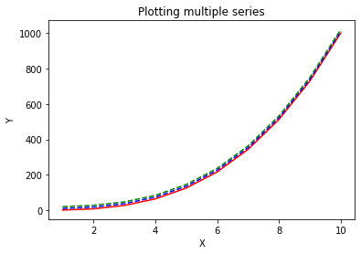

```python
x = [1,2,3,4,5,6,7,8,9,10]
y2 = [1,8,27,64,125,216,343,512,729,1000]
y3 = [10,18,37,74,135,226,353,522,739,1010]
y4 = [20,28,47,84,145,236,363,532,749,1020]
result = plt.plot(x,y2,'r-',x,y3,'b--',x,y4,'g--')
plt.xlabel('X')
plt.ylabel('Y')
plt.title('Plotting multiple series')
plt.show()
```

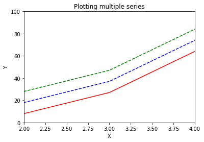

```python
result = plt.plot(x,y2,'r-',x,y3,'b--',x,y4,'g--')
plt.xlabel('X')
plt.ylabel('Y')
plt.xlim((2,4)) # Note the limits on the x and y axes.
plt.ylim((0,100))
plt.title('Plotting multiple series')
plt.show()
```

## Line Properties and Setter methods

`plot()` returns a list of `Line2D` objects encoding the lines shown to the user. The properties of lines can be changed using so-called **setter methods**.

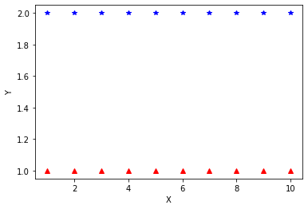

```python
x = [1,2,3,4,5,6,7,8,9,10]
y = [1,1,1,1,1,1,1,1,1,1]
y2 =[2,2,2,2,2,2,2,2,2,2]
result = plt.plot(x,y,'', x, y2, '-') # Note the alternating arguments
plt.setp(result[0], color='r', marker='^',linewidth=0)
plt.setp(result[1], color='b', marker='*', linewidth=0)
plt.xlabel('X')
plt.ylabel('Y')
plt.show()
```

A list of `Line2D` properties can be found at https://matplotlib.org/api/_as_gen/matplotlib.lines.Line2D.html#matplotlib.lines.Line2D.

However, it is also possible to use the result of `plot()` to obtain them.

```python
# show a list of line properties that can be manipulated.
plt.setp(result)
```

```
  agg_filter: a filter function, which takes a (m, n, 3) float array and a dpi value, and returns a (m, n, 3) array
  alpha: float
  animated: bool
  antialiased or aa: bool
  clip_box: `.Bbox`
  clip_on: bool
  clip_path: [(`~matplotlib.path.Path`, `.Transform`) | `.Patch` | None]
  color or c: color
  contains: callable
  dash_capstyle: {'butt', 'round', 'projecting'}
  dash_joinstyle: {'miter', 'round', 'bevel'}
  dashes: sequence of floats (on/off ink in points) or (None, None)
  drawstyle or ds: {'default', 'steps', 'steps-pre', 'steps-mid', 'steps-post'}, default: 'default'
  figure: `.Figure`
  fillstyle: {'full', 'left', 'right', 'bottom', 'top', 'none'}
  gid: str
  in_layout: bool
  label: object
  linestyle or ls: {'-', '--', '-.', ':', '', (offset, on-off-seq), ...}
  linewidth or lw: float
  marker: marker style
  markeredgecolor or mec: color
  markeredgewidth or mew: float
  markerfacecolor or mfc: color
  markerfacecoloralt or mfcalt: color
  markersize or ms: float
  markevery: None or int or (int, int) or slice or List[int] or float or (float, float)
  path_effects: `.AbstractPathEffect`
  picker: float or callable[[Artist, Event], Tuple[bool, dict]]
  pickradius: float
  rasterized: bool or None
  sketch_params: (scale: float, length: float, randomness: float)
  snap: bool or None
  solid_capstyle: {'butt', 'round', 'projecting'}
  solid_joinstyle: {'miter', 'round', 'bevel'}
  transform: `matplotlib.transforms.Transform`
  url: str
  visible: bool
  xdata: 1D array
  ydata: 1D array
  zorder: float
```

## Using Numpy and Pandas

Though it is possible to use simple lists as the input to be plotted, it is more convenient and flexible to use NumPy arrays, or Pandas DataFrames.

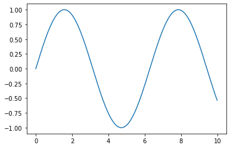

```python
x = np.arange(0.0, 10.0, 0.01) # np.arrange(start, stop, step); returns an ndarray object.
y = np.sin(x);
plt.plot(x, y)
plt.show()
```

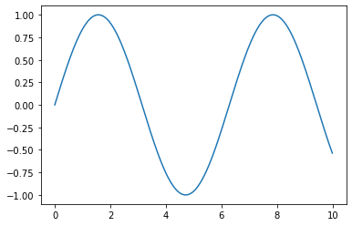

```python
import pandas as pd
df = pd.DataFrame([x,y])
df = df.T
df.columns = ['a', 'b']
plt.plot(df['a'], df['b'])
```

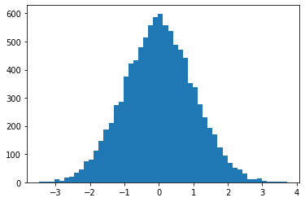

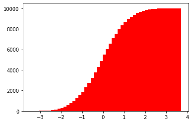

```python
x = np.random.randn(10000) # generate 10,000 points from the standard normal distribution (sd=1, mean=0)
plt.hist(x, bins=50)
plt.show()

plt.hist(x, bins=50, cumulative=True, facecolor='r',)
plt.show()
```

## Multiple Subplots and Multiple Figures

In a fashion very similar to Matlab, it is possible to create multiple subplots in a single figure, and also separate figures.

When we first invoke `plt`, a figure is initialized, and all subsequent operations apply to it. However, it is possible to create and refer to multiple figures using `plt.figure(n)`. When invoked, this switches which figure is currently active.

To create subplots, we use an expression of the form `plt.sublot(row,cols,index)`, where `index` is a numerical index for the subblot, and first two indicate the position of the subplot in a grid.

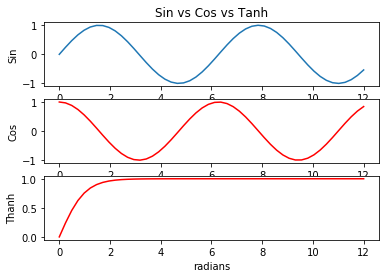

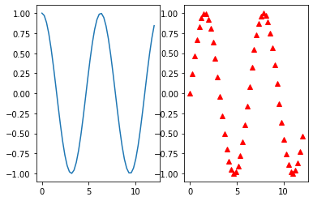

```python
x = np.linspace(0.0, 12.0)

y1 = np.sin(x)
y2 = np.cos(x)
y3 = np.tanh(x)

plt.figure(1)

plt.subplot(3, 1, 1)
plt.plot(x, y1, '-')
plt.title('Sin vs Cos vs Tanh')
plt.ylabel('Sin')

plt.subplot(3, 1, 2)
plt.plot(x, y2, 'r-')
plt.ylabel('Cos')

plt.subplot(3, 1, 3)
plt.plot(x, y3, 'r-')
plt.ylabel('Thanh')
plt.xlabel('radians')

plt.figure(2)

plt.subplot(1, 2, 1)
plt.plot(x, y2, '-')

plt.subplot(1, 2, 2)
res = plt.plot(x, y1, 'r^')

plt.figure(1)
plt.show()

plt.figure(2)
plt.show()
pass
```

To retrieve the current figure, use `plt.gcf()`. To clear it, use `plt.clf()`. To close a figure (releasing its memory), use `plt.close()`

The following are from: https://matplotlib.org/api/_as_gen/matplotlib.pyplot.close.html.

- `close()` by itself closes the current figure
- `close(fig)` closes the Figure instance fig
- `close(num)` closes the figure number num
- `close(name)` where name is a string, closes figure with that label
- `close('all')` closes all the figure windows

## Bar Charts

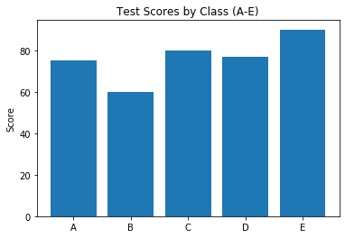

```python
groups = [0,1,2,3,4]
group_titles = ['A','B','C', 'D', 'E']

grparray = np.array(groups)

values = [75,60,80,77,90]

plt.bar(groups, values, align='center')
plt.xticks(groups, group_titles)
plt.ylabel('Score')
plt.title('Test Scores by Class (A-E)')
plt.show()
```

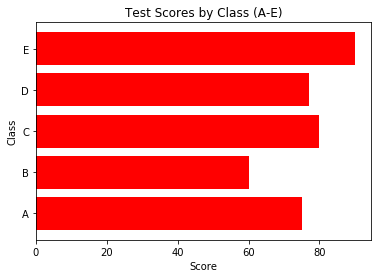

```python
plt.barh(groups, values, align='center', color='red')
plt.yticks(groups, group_titles)
plt.ylabel('Class')
plt.xlabel('Score')
plt.title('Test Scores by Class (A-E)')
plt.show()
```

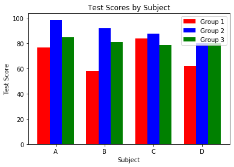

```python
grpA = (77, 58, 84, 62)
grpB = (99, 92, 88, 80)
grpC = (85, 81, 79, 80)

plt.subplots()
index = np.arange(4)
bar_width = 0.25

rects1 = plt.bar(index, grpA, bar_width, color='r', label='Group 1')
rects2 = plt.bar(index + bar_width, grpB, bar_width,color='b', label='Group 2')
rects3 = plt.bar(index + 2*bar_width, grpC, bar_width, color='g',label='Group 3')

plt.xlabel('Subject')
plt.ylabel('Test Score')
plt.title('Test Scores by Subject')
plt.xticks(index + bar_width, ('A', 'B', 'C', 'D'))
plt.legend()
plt.show()
```

## Box plots

```
MIN:  -11.121525640313934
MAX:  30.16913739411464
MEAN:  9.156845759376916
STD:  8.801958294301278
```

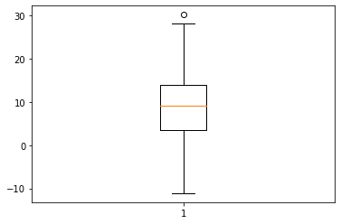

```python
data = np.random.randn(100)*10+10;
print("MIN: ", np.min(data))
print("MAX: ", np.max(data))
print("MEAN: ", np.mean(data))
print("STD: ", np.std(data))
plt.boxplot(data)
pass
```